# Santander Product Recommendation Modelling File

Team: Stat 440 Abe Adeeb, Dani Chu

November 22, 2016

# Introduction

In this competition, we are provided with 1.5 years of customers’ behavior data from Santander bank to predict what new products customers will purchase in the following month, if any. The data starts at 2015-01-28 and contains monthly records of products each customer currently has, such as “credit card”, “savings account”, etc.

### The Data

This dataset includes a variety of data fields we can use as predictions, including:  
- the customer’s age  
- the customer’s sex  
- the customer’s country of residence  
- the customer’s seniority (months)  
- the customer’s gross household income  
- etc.

As seen, we have a number of demographic variables for each individual. Intuitively, these factors should play a very significant role in the way people spend, save, and invest. We also have a record of the product(s) they already currently own, which should also contribute to our exploratory analysis.

### The Objective

The goal of this competition is to predict what additional products a customer will buy in the last month, 2016-06-28, in addition to what products they already possess at 2016-05-28.

# Data Cleaning

Despite the file we were given we did not do any datacleaning as it was shown to make our models worse.

## Create Model

This code tied us with the previous weeks highscore; however, we wrote this code ourselves without taking it from the top teams. The rough strategy is to first find all the customers in their final month before the test data. Then we calculate the most common products owned over all customers in that last month. Next, the strategy is to predict for each customer the 7 most common products that the customer does not already own.

This is done by first calculating all the possible products they could buy, and eliminating the least common products until they hav only purchasable products left.

The next strategy we had did not improve our best model, so the code for it is commented out. The strategy was to predict the 7 most common products for a customers category that each customer didn’t already have. We tried different categories split by variables such as sex, age and segmentation. As the distributions of these variables seemed to indicate a preference for different products. (Graphs Below) This did not improve our best model.

### These graphs show the distributions of products by region

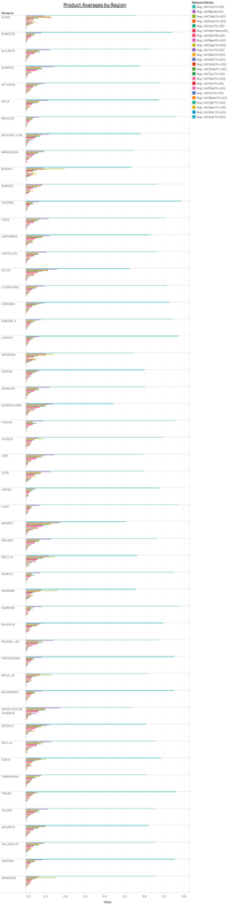

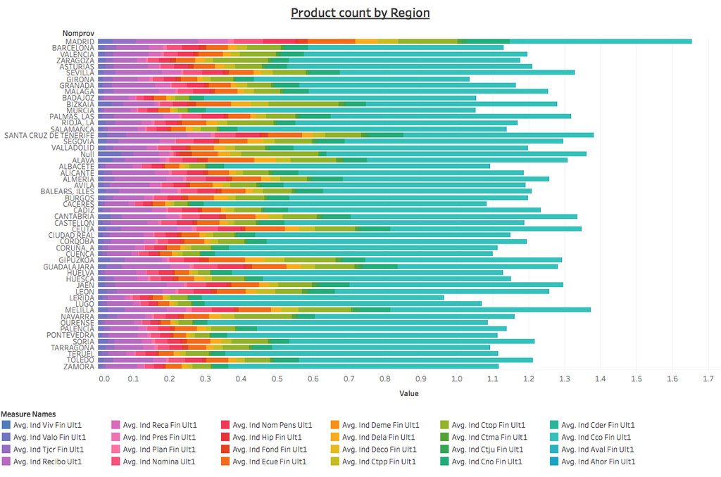

### The distribution of age in the data set, notice the 2 peaks

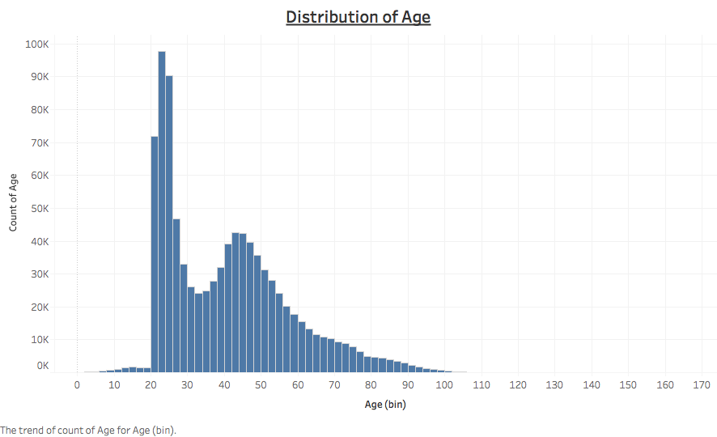

### Product distribution by segmentation, notice the difference in proportional frequency across all 3 categories

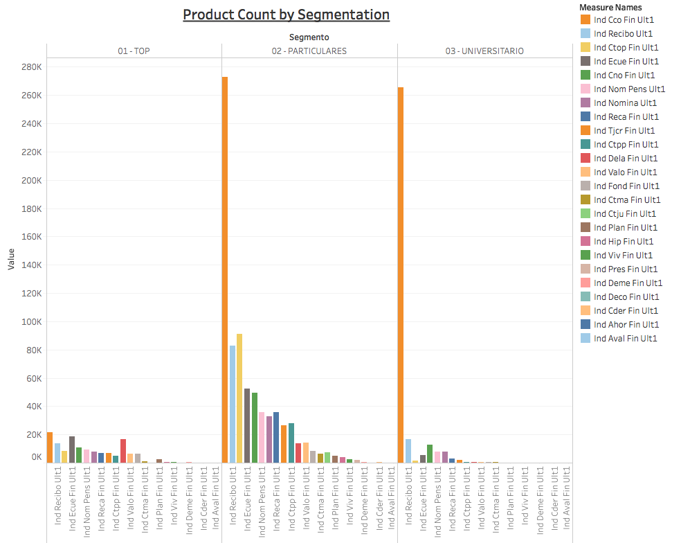

### The distribution of products by sex is fairly similar

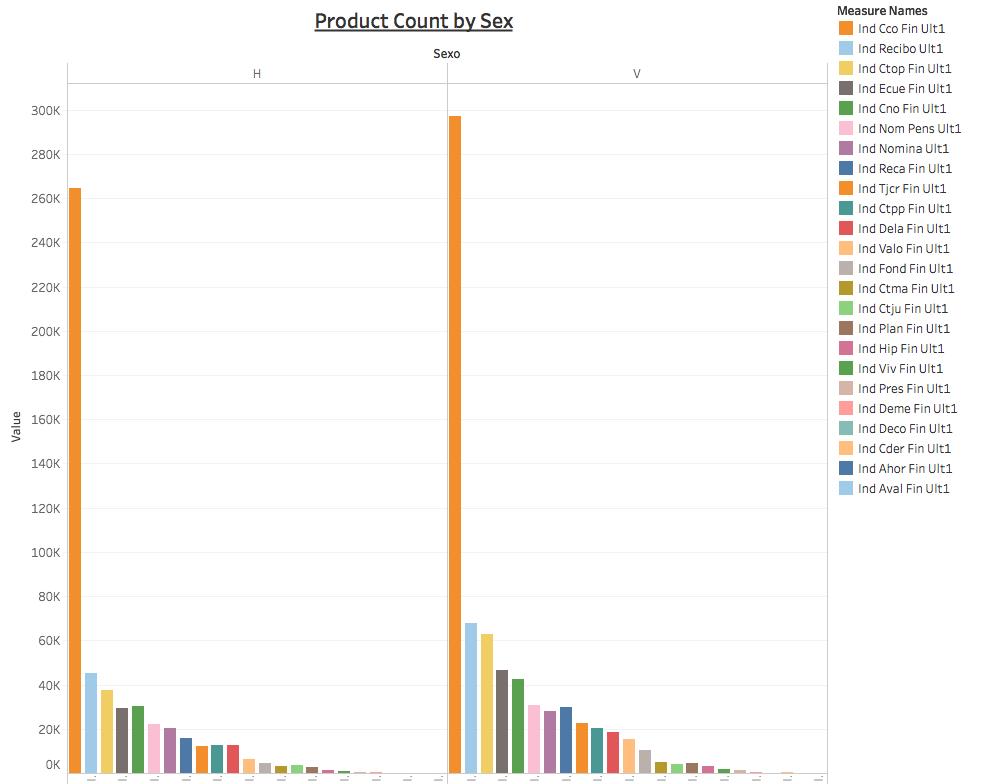

### Total product count that our best model is based off of

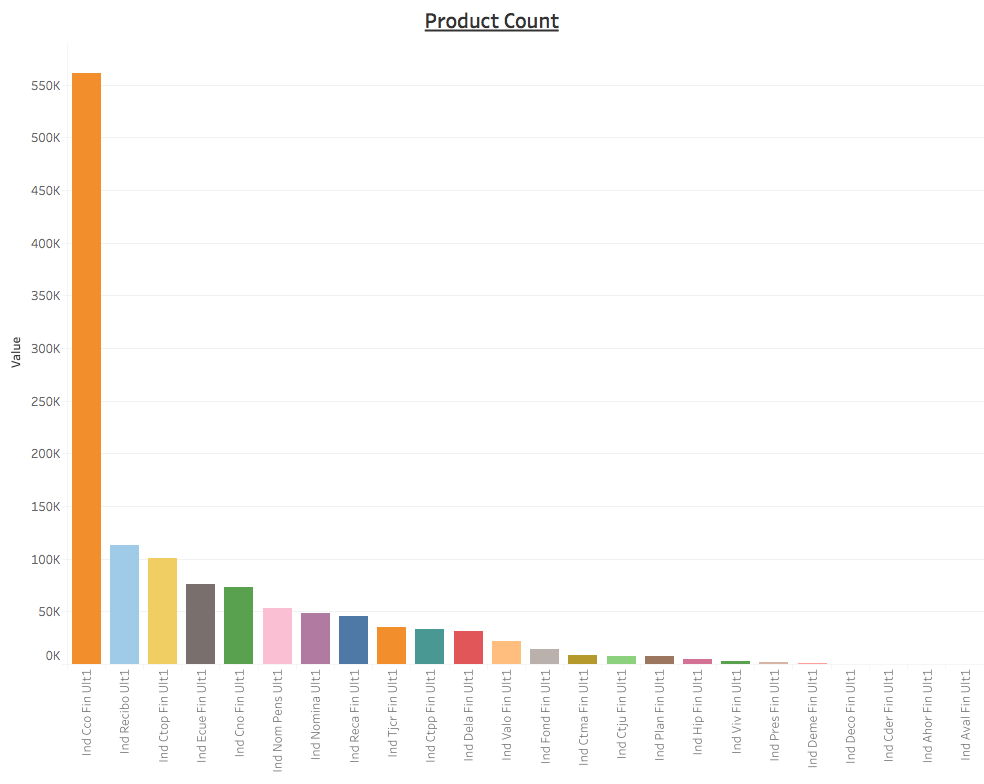

### Product frequency across different ages, age should be indicative of when a product is obtained.

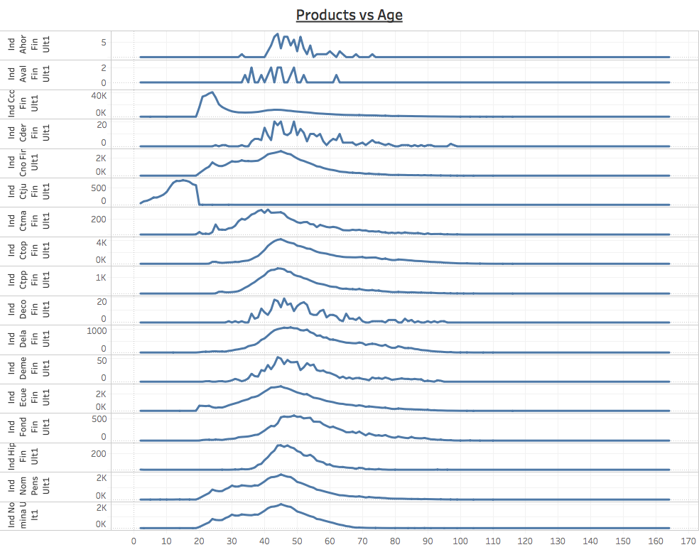

*Note be aware if the lastmonth.csv file hasnt been created then this will not compile. The code to create it is commented out and does not take too long.

I have included the code in the Markdown so the strategy above can be seen in action.

```r
# load in the last months change
system.time(df<-read.csv("lastmonth.csv",header=TRUE))
```

```
##    user  system elapsed
##   20.93    0.81   22.59
```

```r
#Save the max occurences in the most recent month
max_occurences=rep(NA,24)
max_occurences[1]=sum(df$ind_ahor_fin_ult1)
max_occurences[2]=sum(df$ind_aval_fin_ult1)
max_occurences[3]=sum(df$ind_cco_fin_ult1)
max_occurences[4]=sum(df$ind_cder_fin_ult1)
max_occurences[5]=sum(df$ind_cno_fin_ult1)
max_occurences[6]=sum(df$ind_ctju_fin_ult1)
max_occurences[7]=sum(df$ind_ctma_fin_ult1)
max_occurences[8]=sum(df$ind_ctop_fin_ult1)
max_occurences[9]=sum(df$ind_ctpp_fin_ult1)
max_occurences[10]=sum(df$ind_deco_fin_ult1)
max_occurences[11]=sum(df$ind_deme_fin_ult1)
max_occurences[12]=sum(df$ind_dela_fin_ult1)
max_occurences[13]=sum(df$ind_ecue_fin_ult1)
max_occurences[14]=sum(df$ind_fond_fin_ult1)
max_occurences[15]=sum(df$ind_hip_fin_ult1)
max_occurences[16]=sum(df$ind_plan_fin_ult1)
max_occurences[17]=sum(df$ind_pres_fin_ult1)
max_occurences[18]=sum(df$ind_reca_fin_ult1)
max_occurences[19]=sum(df$ind_tjcr_fin_ult1)
max_occurences[20]=sum(df$ind_valo_fin_ult1)
max_occurences[21]=sum(df$ind_viv_fin_ult1)
max_occurences[22]=sum(df$ind_nomina_ult1)
max_occurences[23]=sum(df$ind_nom_pens_ult1)
max_occurences[24]=sum(df$ind_recibo_ult1)

df$condition=NA
# df[df$segmento=="01 - TOP" ,]$condition=1
# df[df$segmento=="02 - PARTICULARES",]$condition=2
# df[df$segmento=="03 - UNIVERSITARIO" ,]$condition=3
df[is.na(df$condition),]$condition=0

df2=df

## read in the test data
test_data <- read.csv('data/test_ver2.csv')

#Save only the first 2 columns as thats all we need
test_data <-test_data[,(1:2)]

#save only the columns needed from the training data, ncodpers and all the product columns
df <- df[df$condition==0,]
df <- df[,c(3,26:49)]

#merge the two datasets
test_merged=merge(x=test_data, y=df, all.x= FALSE, by.x=c("ncodpers"), by.y=c("ncodpers"))

#save the column names
column_name=colnames(df[,2:25])
#column_name=colnames(sex_age[,3:26])

#give max occurences the names of the columns/products
max_occurences=as.data.frame(max_occurences)
max_occurences$column_num=(1:24)
max_occurences$names=column_name[2:25]

#order them by the most popular products
max_occurences = max_occurences[order(max_occurences$max_occurences, decreasing=TRUE),]

#flip 1s to 0s and 0s to 1
test_merged[test_merged==1]=2
test_merged[test_merged==0]=1
test_merged[test_merged==2]=0

#calculate how many products the each customer could buy
test_merged$num_products=apply(test_merged[3:26],1,sum)

#order the columns in merge by popularity of product
index<-max_occurences$column_num+2
test_merged<-test_merged[,c(1,2,index,27)]


#decrease possible product by least likely until only 7 predictions left
for (m in (26:3)){
  test_merged$temp_num_products=test_merged$num_products
  test_merged$num_products[test_merged$num_products>7 & test_merged[,m]==1]=test_merged$num_products[test_merged$num_products>7 & test_merged[,m]==1]-1
  test_merged[test_merged$temp_num_products>7,m]=0
}

#save the columns name for replacing
column_name=colnames(test_merged[,3:25])

# replace all 1s with the column name and 0s with blank string
for (k in 1:24){
  test_merged[test_merged[,2+k]==1,2+k]=column_name[k]
  test_merged[test_merged[,2+k]==0,2+k]=""
}

#concatenate the rows with products to create prediction
preds = apply(test_merged[3:26], 1,paste, collapse=" ")

#get rid of whitespace
preds1=gsub('\\s+', ' ',preds)
preds1=trimws(preds1)

preds1<-data.frame(ncodpers=test_merged$ncodpers, added_products=preds1)

preds2=preds1
```